# Credit Default Swap spreads and Sovereign Ratings

Ivan Rodriguez

April 10, 2015

# Introduction

# Abstract

- Prior literature, most notably Packer and Cantor (1996), has been able to identify most of the key macroeconomic variables that explain the major rating agencies decisions when it come to sovereign ratings.
- However, there has been a great deal of financial innovation over the last 10 years.
- One of the most popular financial instruments that has risen to prominence over the last 10 years is the sovereign credit default swap.
- In this paper, I include the lagged average biennal return as a key variable in the Cantor Packer regression function. I find that information contained in the average credit default swap spread over the last two years is a major determinant in explain the rating agencies’ methodologies.
- Additionally, over time, the power of the spread to single-handedly determine soverign ratings has fallen due to the financial crisis.

# Some Prior Literature

# Cantor Packer (1996)

# Variable Definitions

| Variable | Unit | $\mathbb{E}(Sign)$ | Definition |
| --- | --- | --- | --- |
| ———————– | —— | ————— | ——————————————————– |
| GNI | $ | + | Per capita income at $t-1$ |
| GDP growth | % | + | Average GDP growth from $t-1$ to $t-4$ |
| Inflation | % | - | Average inflation from $t-1$ to $t-3$ |
| Fiscal Balance | % | + | Average fiscal balance relative to GDP from $t-1$ to $t-3$ |
| External Balance | % | + | Average current account surplus realtive to GDP $t-1$ to $t-3$ |
| External Debt | % | - | Foreign currency debt relative exports at $t-1$ |
| Development Indicator | 1/0 | + | IMF classification at $t$ |
| Default Indicator | 1/0 | - | Default in the last 25 years |
| ———————– | —— | ————— | ——————————————————– |

# Results

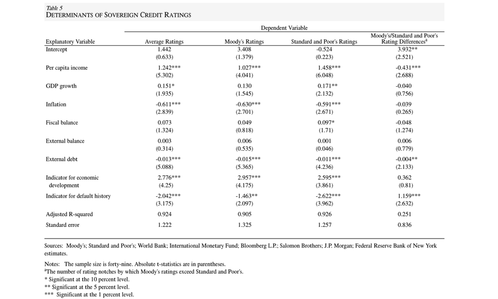

# Conclusions

- They find that 6 variables are important, and their regressions have an $R^2$ of 0.926
- Strongly correlated with bond yield spreads
  - Concludes that ratings agencies’ opinions affect market
- Event study is used to support this finding

### Issues

- Seems ad-hoc: why those 6 variables? Why that averaging scheme?
- Very little robustness checks in paper
- Sample size is small

# Contribution to the Literature

# Replication

**Replication**

|  | *Dependent variable:* |  |  |  |
| --- | --- | --- | --- | --- |
|  | rating |  |  |  |
|  | Moody’s | S&P | Diff | Avg |
|  | (1) | (2) | (3) | (4) |
| log(GNI_cap) | 3.262*** | 2.955*** | 0.307 | 3.109*** |
|  | (1.014) | (0.890) | (0.352) | (0.938) |
| GDP_grw | 0.340 | 0.440** | -0.100 | 0.390* |
|  | (0.234) | (0.205) | (0.081) | (0.216) |
| log(inf) | -1.557 | -2.046* | 0.488 | -1.802 |
|  | (1.211) | (1.063) | (0.421) | (1.120) |
| ext_bal | 0.118 | 0.187** | -0.068** | 0.152* |
|  | (0.095) | (0.083) | (0.033) | (0.088) |
| fsc_bal | 0.230* | 0.173 | 0.057 | 0.201 |
|  | (0.130) | (0.114) | (0.045) | (0.121) |
| ext_dbt | 0.002 | 0.003 | -0.002* | 0.002 |
|  | (0.003) | (0.002) | (0.001) | (0.003) |
| def | -0.590 | 0.479 | -1.069* | -0.055 |
|  | (1.544) | (1.355) | (0.536) | (1.428) |
| dev | -1.132 | -1.098 | -0.034 | -1.115 |
|  | (1.885) | (1.655) | (0.655) | (1.743) |
| Constant | -19.044* | -16.807* | -2.237 | -17.925* |
|  | (9.719) | (8.530) | (3.377) | (8.987) |
| Observations | 40 | 40 | 40 | 40 |
| R<sup>2</sup> | 0.719 | 0.760 | 0.296 | 0.744 |
| Adjusted R<sup>2</sup> | 0.647 | 0.698 | 0.114 | 0.678 |
| Residual Std. Error (df = 31) | 2.939 | 2.579 | 1.021 | 2.717 |
| F Statistic (df = 8; 31) | 9.917*** | 12.264*** | 1.629 | 11.267*** |
| *Note:* | p<0.1; p<0.05; p<0.01 |  |  |  |

# Somes Notes

- With this newer data set, it seems like some of these factors are important, but the individual impact may have fallen over time
- Why?
  - Change in methodology - more data and computing power
  - Maybe more weight given to non-economic factors?
- Is there another variable that can better explain the current rating design used by the agencies?

# Adding CDS Spreads into the Mix

# Cross-sectional Results - Univariate (*PRELIMINARY*)

**Univariate**

|  | *Dependent variable:* |  |  |  |  |  |  |  |  |  |
| --- | --- | --- | --- | --- | --- | --- | --- | --- | --- | --- |
|  | rating |  |  |  |  |  |  |  |  |  |
|  | (1) | (2) | (3) | (4) | (5) | (6) | (7) | (8) | (9) | (10) |
| log(CDS) | -3.874*** | -4.201*** | -4.779*** | -4.841*** | -5.105*** | -3.520*** | -4.016*** | -4.523*** | -4.542*** | -4.720*** |
|  | (0.204) | (0.288) | (0.363) | (0.360) | (0.469) | (0.177) | (0.278) | (0.322) | (0.372) | (0.458) |
| Constant | 25.913*** | 29.914*** | 34.283*** | 34.746*** | 35.725*** | 24.380*** | 28.706*** | 32.729*** | 33.240*** | 33.672*** |
|  | (0.929) | (1.453) | (1.879) | (1.844) | (2.382) | (0.795) | (1.383) | (1.668) | (1.905) | (2.323) |
| Observations | 34 | 35 | 40 | 43 | 41 | 33 | 34 | 40 | 43 | 41 |
| R<sup>2</sup> | 0.918 | 0.865 | 0.820 | 0.815 | 0.752 | 0.927 | 0.867 | 0.839 | 0.784 | 0.731 |
| Adjusted R<sup>2</sup> | 0.916 | 0.861 | 0.816 | 0.811 | 0.746 | 0.925 | 0.863 | 0.834 | 0.779 | 0.725 |
| Residual Std. Error | 1.385 (df = 32) | 1.769 (df = 33) | 2.106 (df = 38) | 2.110 (df = 41) | 2.506 (df = 39) | 1.159 (df = 31) | 1.607 (df = 32) | 1.870 (df = 38) | 2.179 (df = 41) | 2.444 (df = 39) |
| F Statistic | 359.762*** (df = 1; 32) | 212.213*** (df = 1; 33) | 173.581*** (df = 1; 38) | 180.804*** (df = 1; 41) | 118.277*** (df = 1; 39) | 395.501*** (df = 1; 31) | 208.210*** (df = 1; 32) | 197.342*** (df = 1; 38) | 149.207*** (df = 1; 41) | 106.245*** (df = 1; 39) |
| *Note:* | p<0.1; p<0.05; p<0.01 |  |  |  |  |  |  |  |  |  |

- Interesting results
- The $R^2$’s seem to decline over time. Something to do with the financial crisis?

# Cross-sectional Results - Multivariate (*PRELIMINARY*)

```r
#Results - Crossectional Regression by Agency
results_multi <- group_by(reg_data, agency, year) %>%
  do(model =
    summary(lm(rating ~ log(GNI_cap) + GDP_grw + log(inf) + ext_bal + fsc_bal + ext_dbt + def + dev + log(CDS),
               data = .)))
results_multi
```

```
## Source: local data frame [10 x 3]
## Groups: <by row>
##
##     agency year           model
## 1  Moody's 2008 <S3:summary.lm>
## 2  Moody's 2009 <S3:summary.lm>
## 3  Moody's 2010 <S3:summary.lm>
## 4  Moody's 2011 <S3:summary.lm>
## 5  Moody's 2012 <S3:summary.lm>
## 6      S&P 2008 <S3:summary.lm>
## 7      S&P 2009 <S3:summary.lm>
## 8      S&P 2010 <S3:summary.lm>
## 9      S&P 2011 <S3:summary.lm>
## 10     S&P 2012 <S3:summary.lm>
```

```r
results_multi[[3]]
```

```
## [[1]]
##
## Call:
## lm(formula = rating ~ log(GNI_cap) + GDP_grw + log(inf) + ext_bal +
##     fsc_bal + ext_dbt + def + dev + log(CDS), data = .)
##
## Residuals:
##      Min       1Q   Median       3Q      Max
## -1.58234 -0.87577 -0.00288  0.58143  2.22443
##
## Coefficients:
##               Estimate Std. Error t value Pr(>|t|)
## (Intercept)  15.966168   4.292611   3.719  0.00107 **
## log(GNI_cap)  0.643711   0.442217   1.456  0.15845
## GDP_grw       0.172158   0.128493   1.340  0.19285
## log(inf)      0.237559   0.544405   0.436  0.66647
## ext_bal      -0.012253   0.027780  -0.441  0.66311
## fsc_bal       0.140898   0.075576   1.864  0.07455 .
## ext_dbt      -0.001275   0.002313  -0.551  0.58655
## def          -0.437056   0.632501  -0.691  0.49620
## dev           1.858959   1.198019   1.552  0.13382
## log(CDS)     -3.248234   0.427015  -7.607 7.61e-08 ***
## ---
## Signif. codes:  0 '***' 0.001 '**' 0.01 '*' 0.05 '.' 0.1 ' ' 1
##
## Residual standard error: 1.146 on 24 degrees of freedom
## Multiple R-squared:  0.9581, Adjusted R-squared:  0.9423
## F-statistic: 60.93 on 9 and 24 DF,  p-value: 2.399e-14
##
##
## [[2]]
##
## Call:
## lm(formula = rating ~ log(GNI_cap) + GDP_grw + log(inf) + ext_bal +
##     fsc_bal + ext_dbt + def + dev + log(CDS), data = .)
##
## Residuals:
##     Min      1Q  Median      3Q     Max
## -2.2483 -0.6891  0.1421  0.5743  2.7350
##
```

[output cut: 249 more lines]

```
## GDP_grw      -0.0234686  0.1385612  -0.169  0.86664
## log(inf)     -0.6676116  0.6668293  -1.001  0.32475
## ext_bal       0.0645310  0.0527322   1.224  0.23057
## fsc_bal      -0.1224073  0.0795441  -1.539  0.13432
## ext_dbt       0.0004399  0.0014920   0.295  0.77014
## def          -0.0528899  0.8195835  -0.065  0.94897
## dev           1.8749194  1.0740792   1.746  0.09112 .
## log(CDS)     -3.9690695  0.5333133  -7.442 2.71e-08 ***
## ---
## Signif. codes:  0 '***' 0.001 '**' 0.01 '*' 0.05 '.' 0.1 ' ' 1
##
## Residual standard error: 1.554 on 30 degrees of freedom
##   (1 observation deleted due to missingness)
## Multiple R-squared:  0.9156, Adjusted R-squared:  0.8903
## F-statistic: 36.18 on 9 and 30 DF,  p-value: 1.065e-13
```

# Next Steps

- Data is an issue
  - Need to further refine and maximize sample size
  - Many regressors and few data points mean less degrees of freedom
  - Power analysis?
  - See if other averaging techniques may arise
  - Is taking the average spread over the year even valid?
- Additional tests
  - It would be nice if this was it…
  - Probit and Logit models?
  - Panel data technique?
  - Sample size will be an issue since we want a balanced panal data set
- Any questions or comments?